# Modelling tree growth with Gaussian processes

Authors

Victor

Lizzie

Published

May 2025

## 1 Gaussian process model?

Following our one-week workshop in Banff, we came up with a new model of tree growth—with a big contribution of Mike Betancourt. The model is based on Gaussian processes.

### 1.1 A quick overlook of Gaussian processes

From a simplified (and likely eroneous?) point of view, a (finite-$\mathrm{N}$-dimensional projection) of a Gaussian process $f_\mathrm{N}$ is defined as:
$$f_\mathrm{N} \sim \text{multinormal}(\mathrm{m}, \mathrm{K})$$
with a certain mean function $\mathrm{m}$ and a covariance matrix $\mathrm{K}$.
In particular, the elements of $\mathrm{K}$ are defined by a covariance function.
In our case (and in most Gaussian process applications), we use an *exponentiated quadratic* function:
$$\forall i,j \in [\![1,\mathrm{N}]\!] \hspace{1cm} \mathrm{k}_{i,j} = {\gamma^2} \exp\left(-\frac{1}{2}\left(\frac{\lvert x_j-x_i \rvert }{\rho}\right)^2\right)$$
This covariance function capture the “link” between observations along a continuous variable, such as time or space.
The function is characterized by two parameters:
- a marginal deviation $\gamma$, which controls the variability around the mean (the intensity?)
- a length scale $\rho$, which controls how long/far the correlations persist

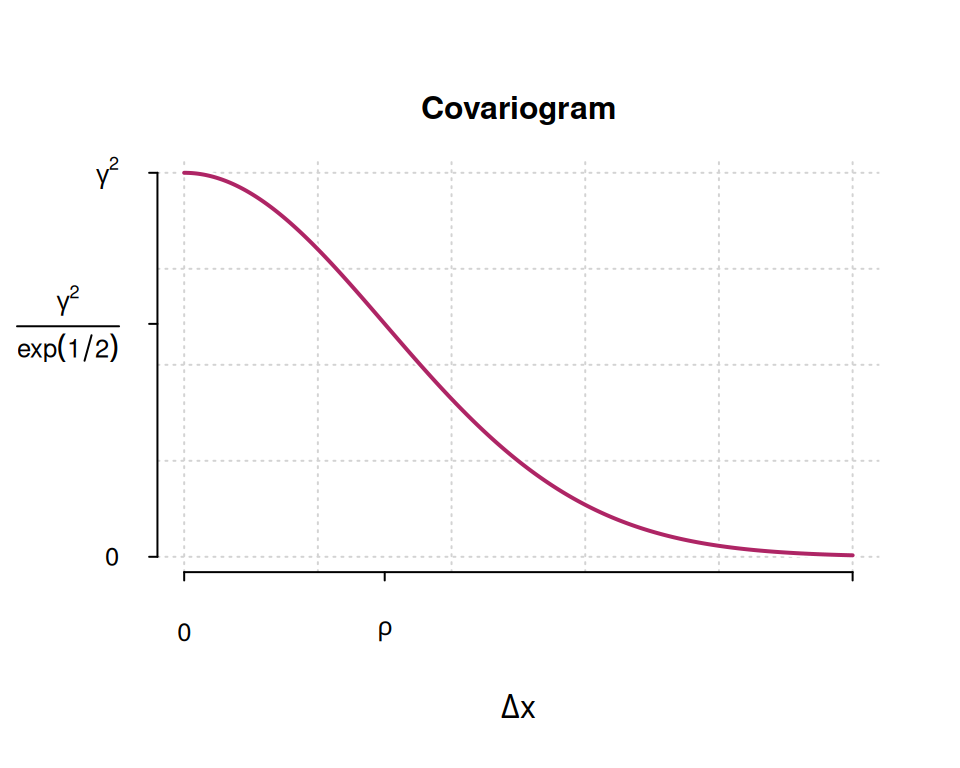

### 1.2 Application to tree growth

Now, let’s say that we have ringwidth measurements $r_w$ for one tree, for each year $x_n$. Using one Gaussian process, a simple model would look like this:

$$\forall x_n \hspace{0.5cm} \log{r_w(x_n)} \sim \text{normal}(\mu + f(x_n), \sigma^2)$$
with:
$$\vec{f} \sim \text{multinormal}(\vec{0}, \mathrm{K})$$
The two equations are equivalent to:

$$\log\vec{{\text{rw}}} \sim \text{multinormal}(\vec{\mu}, \hspace{0.08cm} \Sigma + \mathrm{K})$$
where:

$$\vec{\mu} = \begin{bmatrix}
\mu \\
\mu \\
\vdots \\
\mu
\end{bmatrix}
\hspace{1cm}
\Sigma =
\begin{bmatrix}
\sigma^2 & 0 & \ldots & 0 \\
0 & \ \sigma^2 & \ldots & \vdots\\
\vdots & \vdots & \ddots & \vdots \\
0 & \ldots & \ldots & \sigma^2
\end{bmatrix}$$

In practice, we choose to model the $\log$ of ringwidth with two Gaussian processes:

- one **long-term scale** Gaussian process $f_{\text{long}}$, to capture the long-term variation of tree growth, likely related to allometric constraints
- one **short-term scale** Gaussian process $f_{\text{short,p}}$ per stand $p$, to capture some climatic variations over several years

The long-term scale GP is characterized by one pair of parameters $\{\gamma_{\text{sp}}, \rho_{\text{sp}}\}$ per species $sp$.  
The short-term scale GP is characterized by two parameters $\{\gamma_{\text{short}}, \rho_{\text{short}}\}$, common across all stands. The short-term scale does not depend on species, but its effect is scaled by a factor $\kappa_\text{sp}$ (see below).

We chose two different prior models for these two Gaussian processes, to have the prior mass of $\rho_{\text{short}}$ between 3 and 10 years, and the prior mass of $\rho_{\text{sp}}$ between 20 and 60 years.

The full model is, for $n$ observations for one tree $k$ of the species $sp$ on the stand $p$:

$$\log\vec{\text{rw}}_{sp,p,k} \sim \text{multinormal}(\vec{\mu_{sp,p}}, \hspace{0.08cm} \Sigma + \mathrm{K_{sp}})$$
with:
$$\log\vec{\text{rw}}_{sp,k} =
\log \circ \begin{bmatrix}
\text{rw}_{sp,p,k}(t_1) \\
\text{rw}_{sp,p,k}(t_2) \\
\vdots \\
\text{rw}_{sp,k}(t_n)
\end{bmatrix}
\hspace{1cm}
\log\vec{\mu}_{sp,p} =
\log \circ \begin{bmatrix}
\mu_{sp,p}(t_1) \\
\mu_{sp,p}(t_2) \\
\vdots \\
\mu_{sp,p}(t_n)
\end{bmatrix}$$

$$\forall i \in [\![1,\mathrm{n}]\!] \hspace{0.5cm} \mu_{sp,p}(t_i)= \alpha
+ \beta_{\text{GSL}} * \text{GSL}(p,t_i)
+ \beta_{\text{GDD}} * \text{GDD}(p,t_i)
+ \beta_{\text{SM}} * \text{SM}(p,t_i)
+ \kappa_{\text{sp}}
* f_{\text{short,p}}(t_i)$$

$$\vec{f}_{\text{short,p}} \sim \text{multinormal}(\vec{0}, \mathrm{K_\text{short}})$$

We look at three different climate predictors, at the stand scale:

- the growing season length $\text{GSL}(p,t_i)$, in days
- the growing degree days $\text{GDD}(p,t_i)$ accumulated during the growing season, in $\text{x}10$ $^{\circ}$C
- the mean soil moisture $\text{SM}(p,t_i)$ (weighted average across soil horizons) during the growing season, in $\%$

**Note**

To discuss: do we really need the growing season length?

## 2 Tree growth and climate on Mt Rainier

### 2.1 Study area

We have 16 different plots:

[interactive chart not shown]

and 6 species…

### 2.2 Climate predictors

```r
clim_pred <- readRDS(file.path(wd, "data", "climate","processed_predictors", "wldas_climpredictors.rds"))

clim_pred$soilmoist_ings <- clim_pred$soilmoist_ings*100 # in percentage
clim_pred$gdd_ings <- clim_pred$gdd_ings/10 # in 10degC
```

#### 2.2.1 Soil moisture

As said before, we first investigate the effect of 3 different predictors.  
All of them were extracted from WLDAS (from 1980). We can look at the soil moisture:

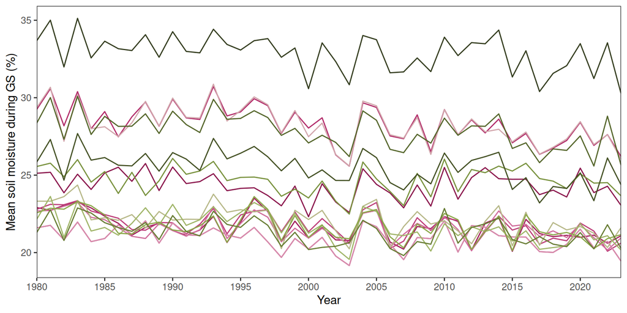

We observe some big difference across stands:

[interactive chart not shown]

**Note**

TO11 has a higher soil moisture than all other plots. From the handbook, this site is ``on a sheltered terrace above the Carbon River.”

If we look at the anomaly from the average stand soil moisture, we observe some similar patterns:

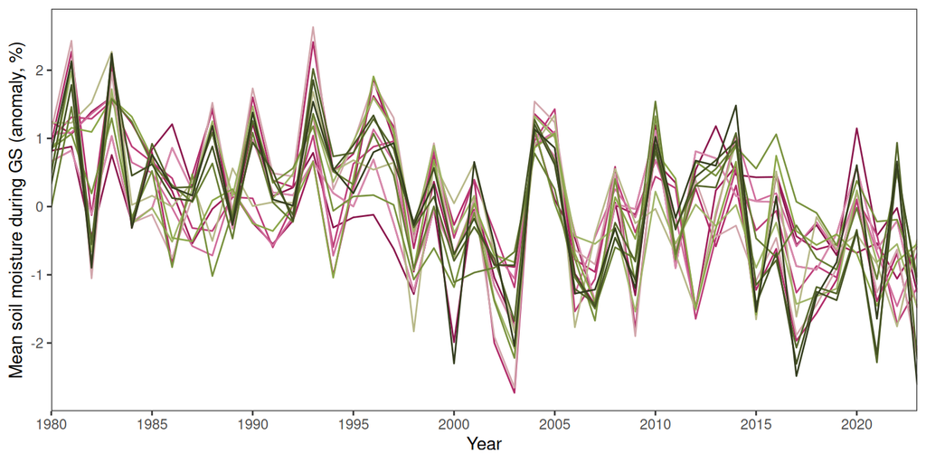

Note that if we look at a fixed time window for all stands (June-August rather than growing season), we find some differences:

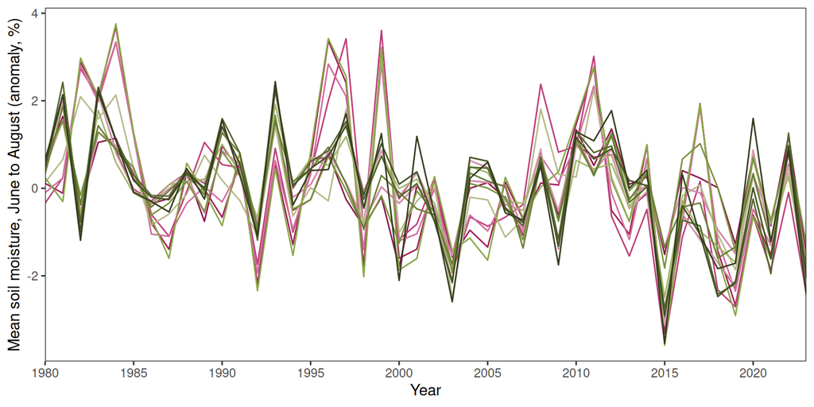

But the spatial pattern across stands is really similar:

[interactive chart not shown]

#### 2.2.2 Growing degree days

We can do the same for GDD:

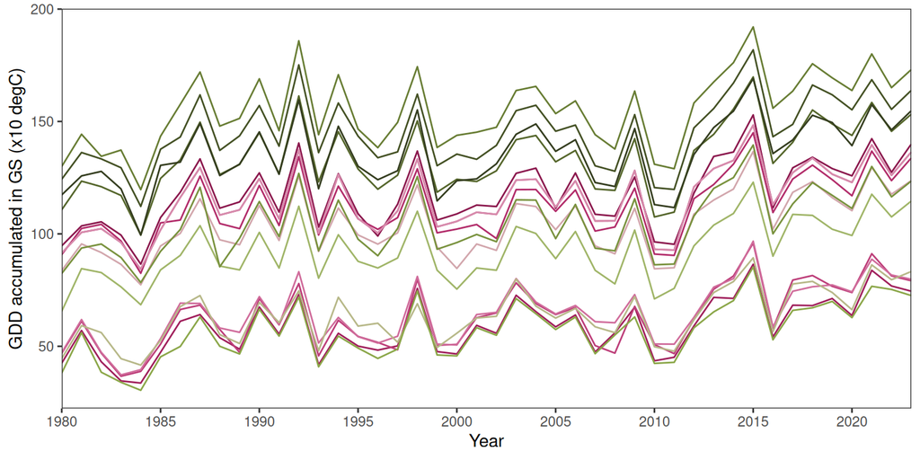

[interactive chart not shown]

If we look at the anomaly from the average stand GDD, we also observe similar patterns:

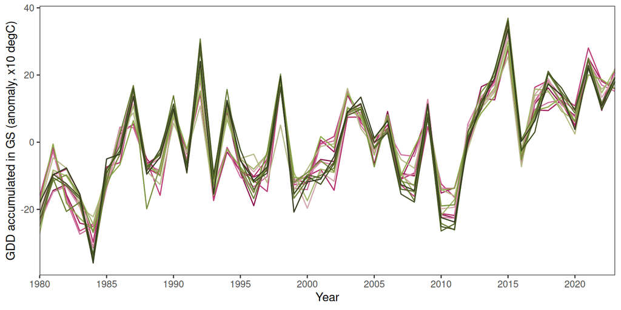

## 3 Model!

Because of the climate we use, we cannot look at ringwidth before 1980. And we don’t have any ring data after 2008 (yet!).

**Warning**

We thus have only kept time series with (at least) continuous measurements from 1980 to 2008.

```r
raw_data <- read.csv(file.path(wd, 'input/treerings/mosttrees_allspecies_allplots_19802008.csv'))

# Average ring widths when both cores are present
robust_ave <- function(x, y) {
  ifelse(is.na(y), x, mean(c(x, y)))
  if (is.na(x)) {
    y
  } else if(is.na(y)) {
    x
  } else {
    mean(c(x, y))
  }
}

raw_data$rw_core_ave..mm. <- as.vector(by(raw_data,
                                          seq_len(nrow(raw_data)),
                                          function(r) robust_ave(r[[6]], r[[7]])))
```

### 3.1 Posterior quantification

```r
runstan <- FALSE

if(runstan){

  fit <- stan(file=file.path(wd, 'stan/model6_with3predictors.stan'),
            data=data, seed = 20012029, cores = 4,
            warmup=1000, iter=2024, refresh=10)
  saveRDS(fit, file = file.path(wd, 'output/fit/model6_with3predictors_19802018.stan'))

}else{

  fit <- readRDS(file = file.path(wd, 'output/fit/model6_with3predictors_19802018.stan'))

}

diagnostics <- util$extract_hmc_diagnostics(fit)
util$check_all_hmc_diagnostics(diagnostics)
```

```
  Divergent Hamiltonian transitions result from unstable numerical
trajectories.  These instabilities are often due to degenerate target
geometry, especially "pinches".  If there are only a small number of
divergences then running with adept_delta larger than 0.801 may reduce
the instabilities at the cost of more expensive Hamiltonian
transitions.
```

```r
samples <- util$extract_expectand_vals(fit)
base_samples <- util$filter_expectands(samples,
                                       c('alpha',
                                         'rho', 'gamma',
                                         'f_tilde_sh',
                                         'rho_sh', 'gamma_sh',
                                         'kappa_sh_free',
                                         'sigma'),
                                       check_arrays=TRUE)
util$check_all_expectand_diagnostics(base_samples)
```

```
All expectands checked appear to be behaving well enough for reliable
Markov chain Monte Carlo estimation.
```

[output not shown]

### 3.2 Retrodictive Check

We first need to validate that our model is adequately capturing the observed data features (before any posterior inference).  
We can look at some trees on one stand.

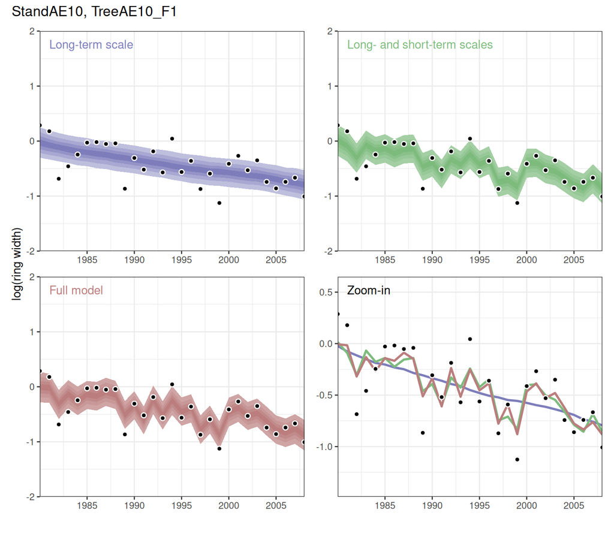

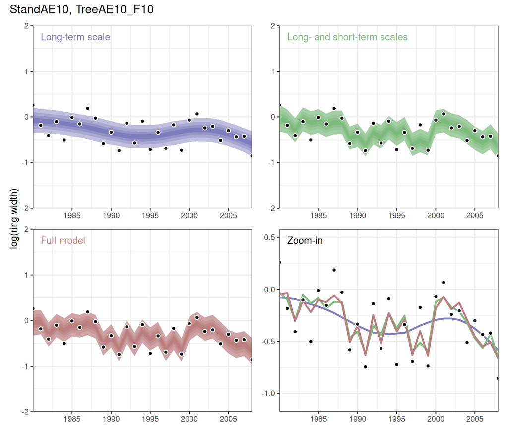

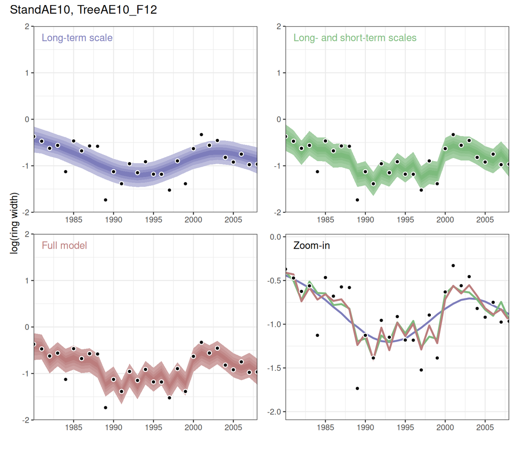

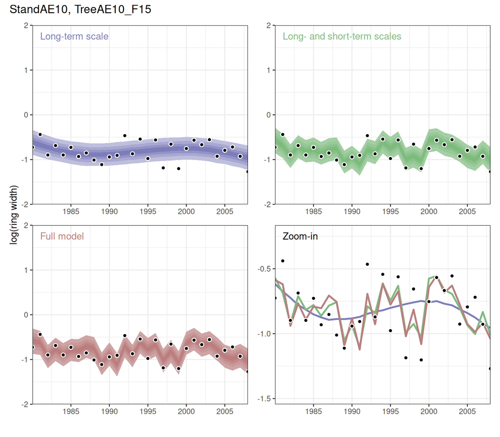

Let’s look at another stand now.

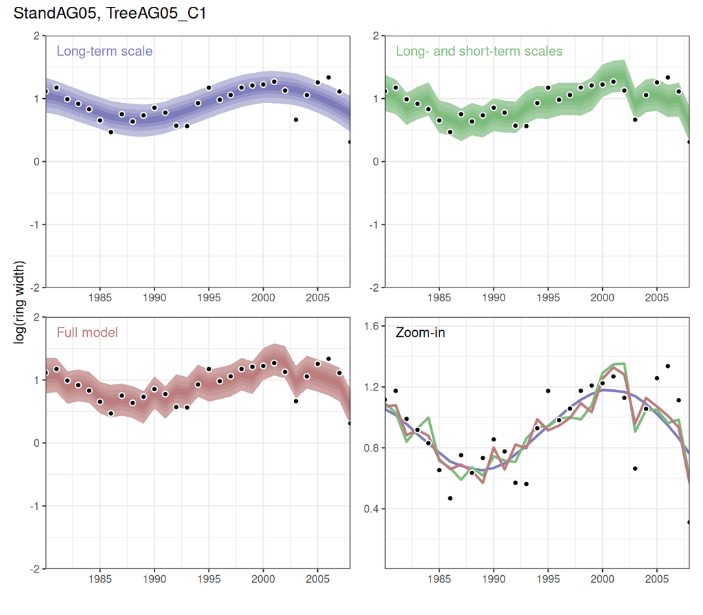

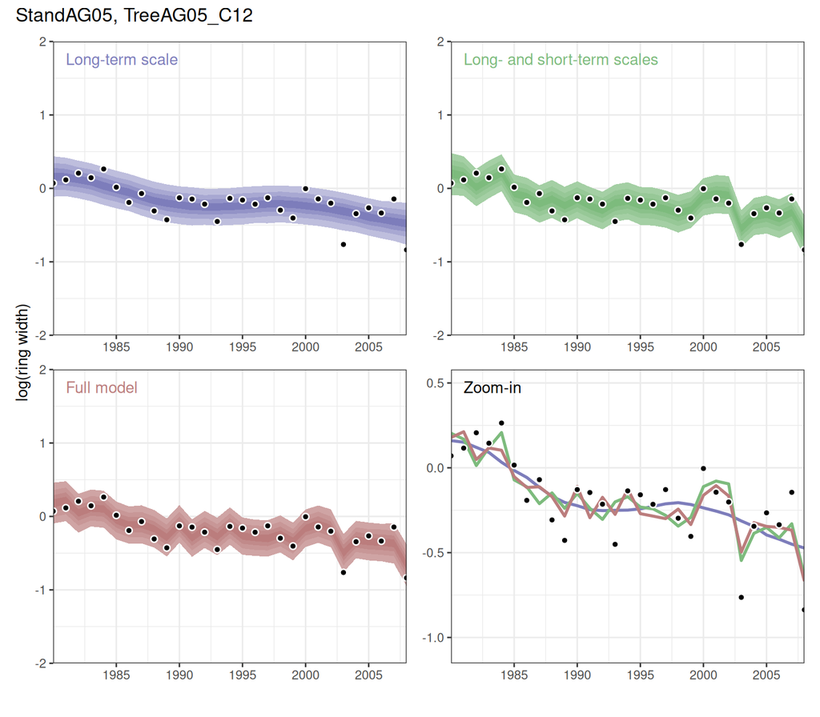

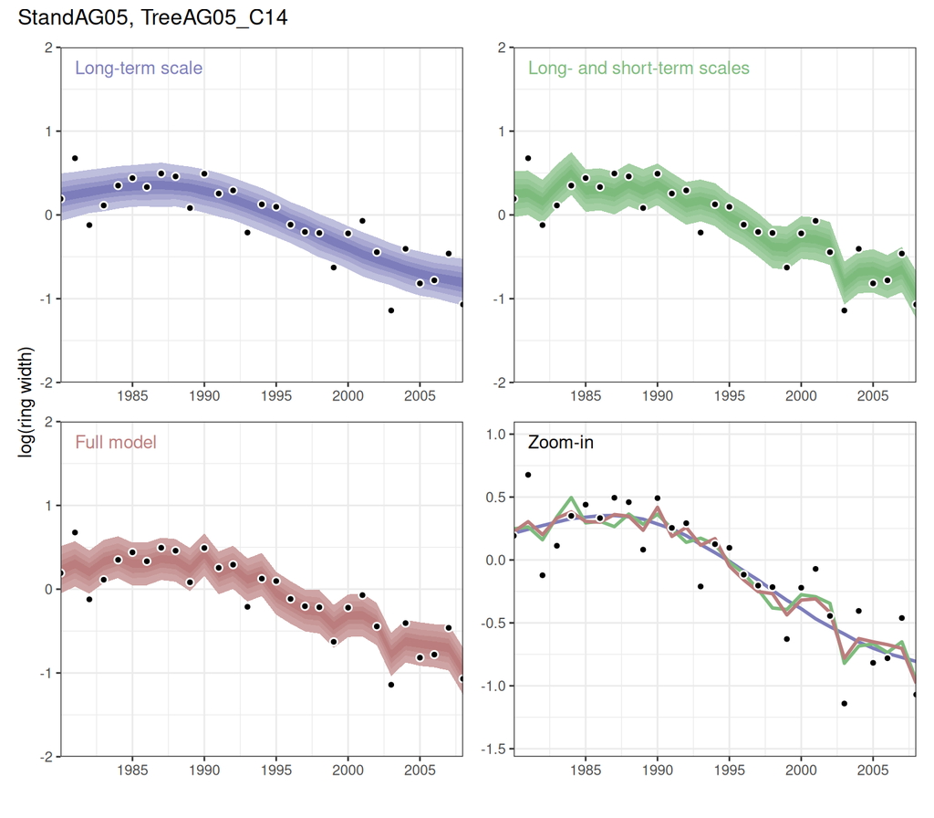

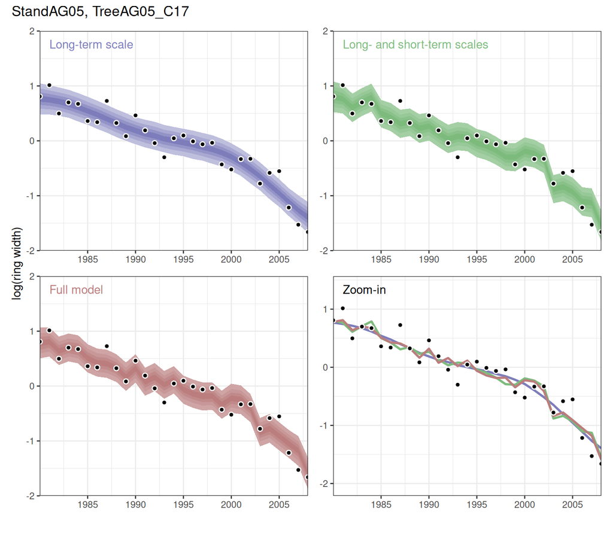

**Note**

We would need to do more retrodictive check…

### 3.3 Posterior inference

#### 3.3.1 Species sensibility to short-term scale variations

Here we look at $\kappa_\text{sp}$, the species-specific factor that scaled the short-term scale GP.

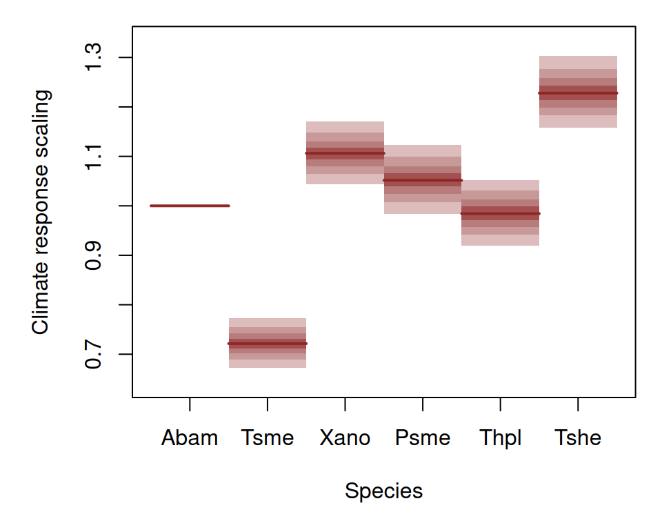

#### 3.3.2 Effects of climate predictors

To investigate the interactions between model outputs and the observed input, we can look at the posterior predictive behaviors of the 3 climate predictors (here, we look at the distribution of posterior sample medians). The posterior (shown in shades of red, representing the different quantiles) falls generally around the observed data (shown in black). Continuous predictors are binned for visualization (gray means no data in that bin). However, for example, at higher GSL the model seems to underpredict the observed log(ring width).

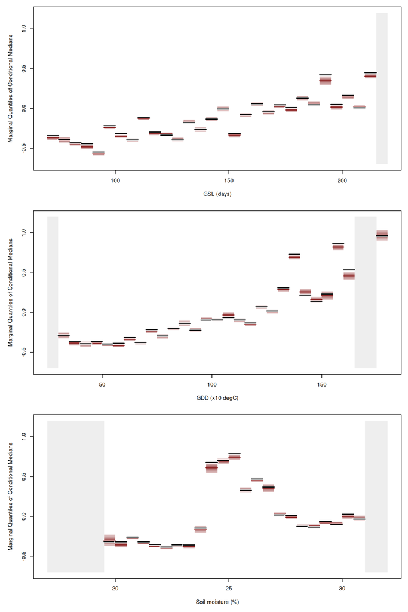

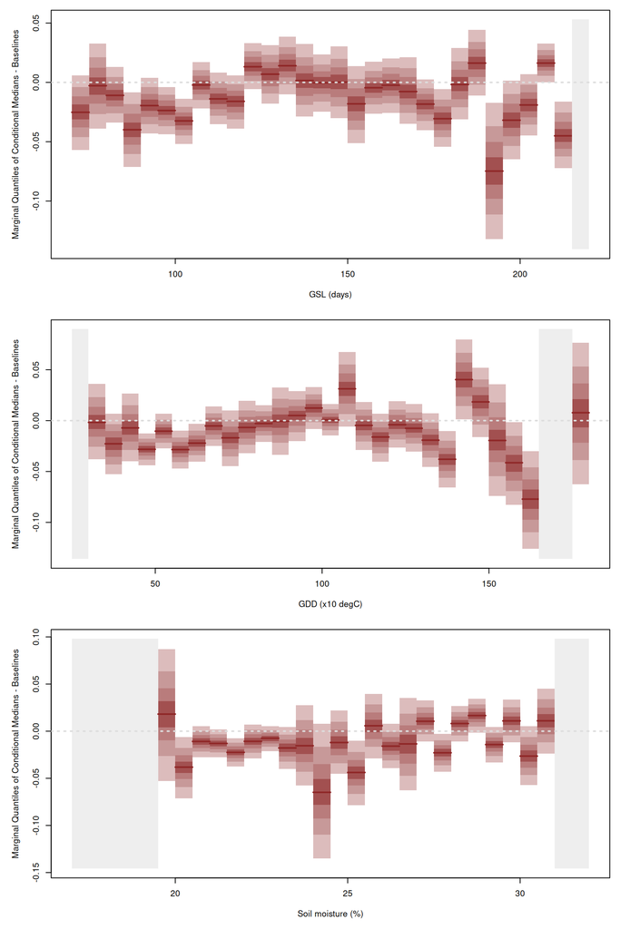

We now look at posterior distributions of $\beta_{\text{GSL}}$, $\beta_{\text{GDD}}$ and $\beta_{\text{SM}}$.

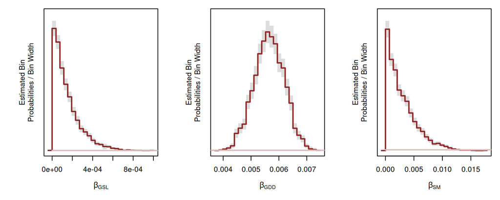

$\beta_{\text{GDD}}$ seems different than zero. We have $\text{median}(\beta_{\text{GDD}})=$ 0.00565 per x10 degC, so an increase of GDD of 500 degC would lead to a proportional ringwidth increase of $\exp(\beta_{\text{GDD}}\times 50)=$ 32.6% (because we work on a log-scale).  
$\beta_{\text{GSL}}$ and $\beta_{\text{SM}}$ are not really different than zero.

**Moving forward**

Average soil moisture (across horizons) during growing season does not seem to be a great predictor of tree ringwidth, in our model.

- Do we have some expertise to explain the posterior predictive behavior of soil mositure, which looks like a bell-shaped curve?
- Can we think of a better predictor related to drought (e.g. VPD?), or another way to include soil moisture? (Note that we obtain more or less the same bell-shaped curve for soil moisture between June and August)
- Using WLDAS limits our analysis to observations after 1980. Should we try other climate datasets with a longer temporal coverage (but likely of poorer quality and resolution)?